# Module Seven Activity

For the module seven activity, you will identify relevant data and write Python code to generate visualizations and interpret insights from the provided data set. Professionals in data-driven fields must not only interpret data but also gather, analyze, and present it in meaningful and actionable ways. This activity allows you to practice these essential skills by working through the complete exploratory data analysis (EDA) process.

*Note:* there are two parts to this assignment. Part One is the coding activity. Part Two is the written report.

Once your code is complete, you will download this notebook as an HTML file by clicking **File**, then **Download As**, then **HTML (.html)** from the Jupyter menu bar. Validate that your code, output, and all visualizations (rendered as images using the display() function) are visible in the html file before submission.

*Missing Blocks:* Ensure that you have clicked **Run** for all blocks before downloading as an HTML file or the block may be missing from your submission. **Images** must be called using the *display()* function, for example: **display(Image(filename="output/{image_name}.png"))**

Specifically, you must address the items from the rubric criteria.

### Part One: Python Code

In this part, you will write Python code to analyze the data and generate visualizations that explore trends.

#### Create multiple, distinct visualizations that explore different aspects of the data using Python Libraries.

Include the following:

- Code comments explaining each step of your analysis

### Part Two: Report

In this part, you will write a reflection to explain the insights gained from your analysis and visualizations. *This part is to be completed in a word document, using the output here to answer the topics.*

- Explain the trends, differences, or outliers you observed in the data.
- Describe any disparities or patterns that may be relevant to the nonprofit’s goals.
- Write a summary of what the data suggests about transit usage across neighborhoods.
- Explain how the visualizations support your conclusions.
- Discuss how your findings could inform the nonprofit’s decision-making or strategy.
- Describe the importance of data-driven insights in addressing real-world challenges.

*To Begin:* This Python template program has been broken down into segments as a guide for what steps you should do at a minimum to complete this activity. Look for the **# To Do:** comments. These are placeholders for you to provide Python code segments. Fill out all **# To Do:** code segments to complete this program.  
*Once Complete:* Execute a "Kernel restart and run all" to verify that all your code works as a single unit by clicking **Kernel**, then **Restart & Run All** before downloading as html.

*Hint:* If you need to install additional packages, see one of the earlier modules on how to configure and call a requirements.txt file.

## Import the Required Packages

```python
import pandas as pd
import matplotlib.pyplot as plt
import seaborn as sns
import os
import matplotlib.image as mpimg
import re

from IPython.display import Image, display # for image rendering in html output
```

# Part One: Python Code

*Reminder:* Ensure that you add code comments explaining each step of your analysis.

## Define the file path for the dataset

```python
data_path = "data/Feb_2025_Complete_Monthly_Ridership.csv"
```

## Loading the dataset

```python
# To Do: Load the dataset
df = pd.read_csv(data_path)
```

## Create an output folder if it doesn't already exist

```python
output_folder = "output"
os.makedirs(output_folder, exist_ok=True)
```

## Display Dataset Information

```python
print("Dataset Overview:")
# To Do: Print the first 5 rows of the dataset to inspect the data to ensure it loaded correctly
print(df.head())
```

```
Dataset Overview:
   NTD ID Legacy NTD ID       Agency Mode TOS 3 Mode
0       1          0001  King County   DR  PT    Bus  \
1       1          0001  King County   DR  TX    Bus
2       1          0001  King County   FB  DO  Ferry
3       1          0001  King County   LR  DO   Rail
4       1          0001  King County   MB  DO    Bus

  Mode/Type of Service Status  Reporter Type
0                      Active  Full Reporter  \
1                      Active  Full Reporter
2                      Active  Full Reporter
3                    Inactive  Full Reporter
4                      Active  Full Reporter

```

[output cut: 36 more lines]

```python
print("Column Names:")
# To Do: Print all column names
print(df.columns.tolist())
```

[output not shown]

```python
neighborhoods = ["King County", "City of Longview", "Spokane Transit Authority"]
# To Do: Filter the data for the three neighborhoods and create an explicit copy
# Use exact matches (not substring search) to avoid false positives like
# "King County Ferry District" or "Licking County, Ohio" incorrectly matching
df_filtered = df[df["Agency"].isin(neighborhoods)].copy()

print(f"Filtered dataset shape: {df_filtered.shape}")
print(df_filtered["Agency"].unique())
```

```
Filtered dataset shape: (17, 27)
['King County' 'Spokane Transit Authority' 'City of Longview']
```

```python
# To Do: Convert numeric columns to proper formats (removing commas and extra spaces)
numeric_cols = [
    "UZA Population", "UZA SQ Miles", "Service Area Population", "Service Area SQ Miles",
    "Passenger Miles FY", "Unlinked Passenger Trips FY", "Fares FY",
    "Operating Expenses FY", "Avg Cost Per Trip FY", "Avg Fares Per Trip FY"
]

for col in numeric_cols:
    df_filtered[col] = (
        df_filtered[col]
        .astype(str)
        .str.replace(",", "", regex=False)
        .str.strip()
    )
    df_filtered[col] = pd.to_numeric(df_filtered[col], errors="coerce")

print(f"Converted {len(numeric_cols)} columns to numeric.")
print(df_filtered[numeric_cols].dtypes)
```

```
Converted 10 columns to numeric.
UZA Population                 float64
UZA SQ Miles                   float64
Service Area Population        float64
Service Area SQ Miles          float64
Passenger Miles FY               int64
Unlinked Passenger Trips FY      int64
Fares FY                       float64
Operating Expenses FY          float64
Avg Cost Per Trip FY           float64
Avg Fares Per Trip FY          float64
dtype: object
```

## Generate, Save, and Output Visualizations

*Example Visualizations:* The three visualization placeholders below are example visualization placeholders for the data using a provided template. These are simple example frameworks that you may use, but you may, and are encouraged to develop your own visualizations that you will then explain how the selected visualizations support your conclusions in the part two report.

In accordance with the scenario, three neighborhoods for evaluation are: King County, City of Longview, and Spokane Transit Authority which have been listed in the neighborhoods variable above.

This is an example visualization you can generate. You may implement a chart and assessment of your choosing in lieu of this placeholder.

#### At a minimum include the following actions:

- Add title and axis labels
- Save the plot to a png file in the 'output' folder
- Use the display() function to render the generated png image in the html output
- Comments explaining each step of your analysis

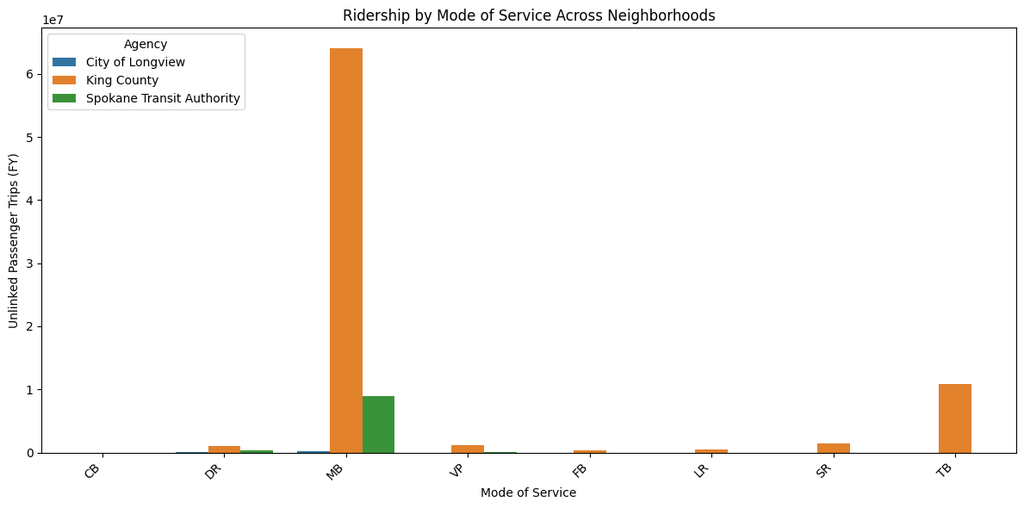

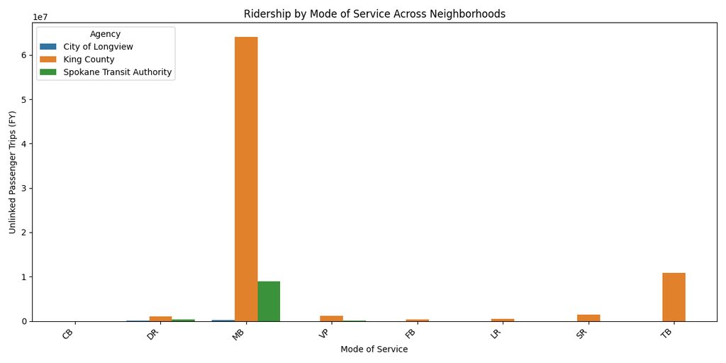

```python
# To Do: Create a visualization that will support your conclusions for part two
# NOTE: This file is a single-period snapshot (one row per agency per mode), not a
# monthly time series, so a literal "trend over years" isn't possible with this data.
# Instead, this chart breaks down ridership by mode of service per neighborhood,
# which reveals a different kind of pattern: how each area relies on different transit types.
mode_totals = df_filtered.groupby(["Agency", "Mode"])["Unlinked Passenger Trips FY"].sum().reset_index()

plt.figure(figsize=(12, 6))
sns.barplot(data=mode_totals, x="Mode", y="Unlinked Passenger Trips FY", hue="Agency")
plt.title("Ridership by Mode of Service Across Neighborhoods")
plt.xlabel("Mode of Service")
plt.ylabel("Unlinked Passenger Trips (FY)")
plt.xticks(rotation=45, ha="right")
plt.legend(title="Agency")
plt.tight_layout()

plt.savefig(os.path.join(output_folder, "ridership_by_mode.png"))
plt.show()
display(Image(filename=os.path.join(output_folder, "ridership_by_mode.png")))
```

### Visualization 2: Bar chart comparing total ridership across neighborhoods

This is an example visualization you can generate. You may implement a chart and assessment of your choosing in lieu of this placeholder.

#### At a minimum include the following actions:

- Add title and axis labels
- Save the plot to a png file in the 'output' folder
- Use the display() function to render the generated png image in the html output
- Comments explaining each step of your analysis

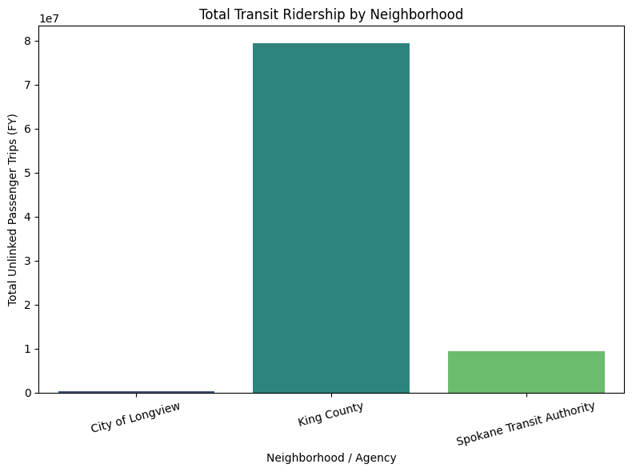

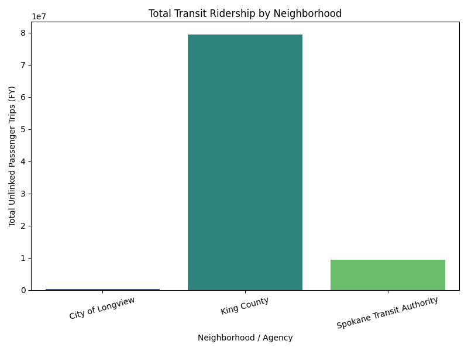

```python
# To Do: Create a visualization that will support your conclusions for part two
total_by_agency = df_filtered.groupby("Agency")["Unlinked Passenger Trips FY"].sum().reset_index()

plt.figure(figsize=(8, 6))
sns.barplot(data=total_by_agency, x="Agency", y="Unlinked Passenger Trips FY", palette="viridis")
plt.title("Total Transit Ridership by Neighborhood")
plt.xlabel("Neighborhood / Agency")
plt.ylabel("Total Unlinked Passenger Trips (FY)")
plt.xticks(rotation=15)
plt.tight_layout()

plt.savefig(os.path.join(output_folder, "total_ridership_bar.png"))
plt.show()
display(Image(filename=os.path.join(output_folder, "total_ridership_bar.png")))
```

### Visualization 3: Scatterplot of ridership vs population

This is an example visualization you can generate. You may implement a chart and assessment of your choosing in lieu of this placeholder.

#### At a minimum include the following actions:

- Add title and axis labels
- Save the plot to a png file in the 'output' folder
- Use the display() function to render the generated png image in the html output
- Comments explaining each step of your analysis

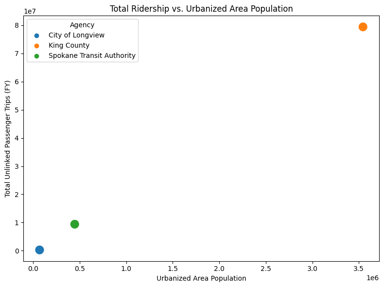

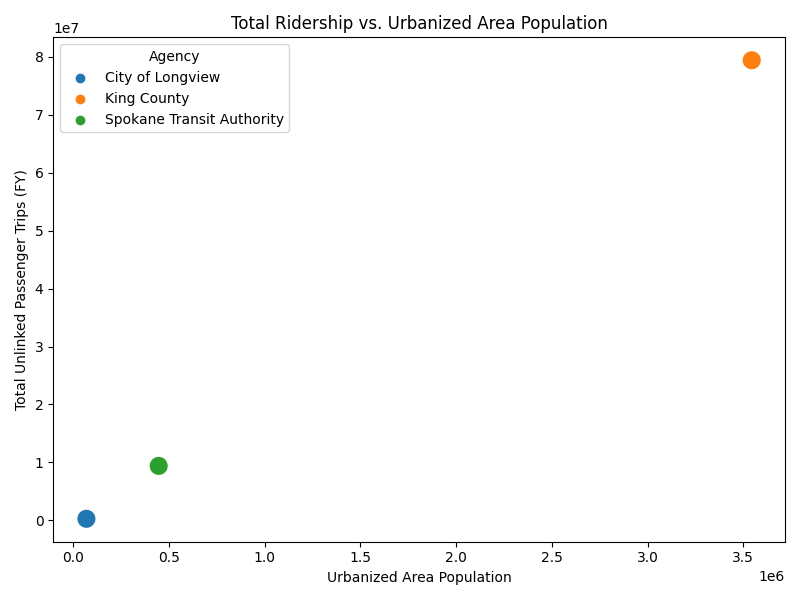

```python
# To Do: Create a visualization that will support your conclusions for part two
pop_data = df_filtered.groupby("Agency")["UZA Population"].first().reset_index()
scatter_data = total_by_agency.merge(pop_data, on="Agency")

plt.figure(figsize=(8, 6))
sns.scatterplot(data=scatter_data, x="UZA Population", y="Unlinked Passenger Trips FY", hue="Agency", s=200)
plt.title("Total Ridership vs. Urbanized Area Population")
plt.xlabel("Urbanized Area Population")
plt.ylabel("Total Unlinked Passenger Trips (FY)")
plt.tight_layout()

plt.savefig(os.path.join(output_folder, "ridership_vs_population.png"))
plt.show()
display(Image(filename=os.path.join(output_folder, "ridership_vs_population.png")))
```